# Random Effects and Model Choice

panel_data_02 · Which variation can we trust?

**The decision:** Should we use random effects (RE) to gain precision, or are between-household differences an unreliable source of information?

Chapter 15, §15.3 and §§15.4–15.4.3, 15.4.5; selected extensions in §15.4.6.

## Before class

Lecture 1 established that FE uses within-household variation and removes stable additive household effects. Only **3.78%** of the liquor sample’s total income variation is within households. Today we ask what assumptions permit the use of the much larger between-household component.

Read §15.3, §§15.4–15.4.3 and §15.4.5, plus the random-effects portion of the supplied handout. Hausman–Taylor (§15.4.4) is optional reference material, not part of this live lab.

**After this lecture, you should be able to:**

- Compare pooled OLS, FE and RE by the variation they use and their assumptions.
- Distinguish coefficient inconsistency from incorrect standard errors.
- Use the LM test to ask whether a household component is present, and the Hausman and Mundlak tests to ask whether it is related to the regressors.
- Defend a model choice using economic reasoning, clustered inference and Mundlak’s approach.

**Must understand:** RE’s additional exogeneity restriction; the conditional nature of efficiency gains; clustering versus bias correction; which question each of the LM, Hausman and Mundlak tests answers; why the conventional Hausman test cannot simply use clustered standard errors; and the within–between interpretation of the Mundlak regression.  
**Reference material:** variance-component estimation and the joint (χ²) form of the Hausman test.  
**No memorisation required:** GLS matrices or variance-component formulas.

### Notation bridge

This lecture follows POE5 for the household effect but uses its own symbols for the RE weights, matching the R script. The same objects appear under different names elsewhere:

| Object | This lecture and script | Handout V2.1 | POE5 | `plm` |
| --- | --- | --- | --- | --- |
| Household effect | $u_i$ | $\alpha_i$ | $u_i$ | individual effect |
| Its variance | $\sigma_u^2$ | $\sigma_\alpha^2$ | $\sigma_u^2$ | `id` |
| Weight on between variation | $\omega$ | $\phi^2$ | – | – |
| Quasi-demeaning parameter | $\lambda=1-\sqrt{\omega}$ | $\theta=1-\phi$ | $\alpha$, eq. 15.34 | `theta` |

POE5’s $\alpha$ is the quasi-demeaning parameter, not an intercept. It runs in the *opposite* direction to $\omega$: POE5’s $\alpha=1$ gives FE and $\alpha=0$ gives pooled OLS, whereas $\omega=1$ gives pooled OLS and $\omega=0$ gives FE.

## 0. Retrieval and connection

Why might the within estimator be imprecise even with 120 observations? Could we use the between-household variation to improve precision?

**Expected answer**

There are 40 household clusters, and little income variation within households. The within slope depends on that variation. Between information might help, but only if its relationship to unobserved household characteristics can be justified.

## 1. The hook

| Model | Income slope | Household-clustered SE |
| --- | --- | --- |
| FE | 0.02074 | 0.01943 |
| RE | 0.02658 | 0.00746 |

An analyst recommends RE because its standard error is smaller. Is that sufficient justification? Think about the assumption you would examine before accepting the recommendation.

Revisit this after the lab session.

## 2. Minimal theory

### Two distinct problems · §§15.3–15.3.2

$$y_{it}=\alpha+\beta x_{it}+u_i+e_{it}.$$

The household component is $u_i$ (time-invariant unobserved heterogeneity); the time-varying error is $e_{it}$. Here $\alpha$ is the intercept.

| Problem | Consequence | Relevant response |
| --- | --- | --- |
| $u_i$ is correlated with income | Pooling and conventional RE may estimate the wrong slope | FE or an appropriate correlated-effects specification |
| Errors are dependent within a household | Conventional standard errors may be wrong | Household-clustered inference |

Clustering changes estimated uncertainty. It does not remove omitted-variable bias. FE removes stable additive household effects, but does not automatically remove dependence in the remaining errors.

### RE connects to GLS · §15.4

Under the standard error-components structure,

$$\operatorname{Cov}(u_i+e_{it},u_i+e_{is})=\sigma_u^2,\quad t\ne s.$$

RE uses this covariance structure through GLS. The connection to SUR is the use of covariance information for efficiency; here the dependence is within households over time. The additional RE exogeneity restriction is

$$E(u_i\mid x_{i1},\ldots,x_{iT})=0.$$

Strict exogeneity of $e_{it}$ remains required. “Random effects” does not merely mean the households were randomly sampled. The key issue for choosing between FE and RE is the permitted relation between the household effect and the regressors.

### Within–between weighting · §15.4 and the handout

For this balanced, single-regressor model with an intercept,

$$\hat\beta_{\mathrm{RE}}=
\frac{W_{xy}+\omega B_{xy}}{W_{xx}+\omega B_{xx}},
\qquad \omega=\frac{\sigma_e^2}{\sigma_e^2+T\sigma_u^2}.$$

Here $B_{xx}=T\sum_i(\bar x_i-\bar x)^2$ and $B_{xy}=T\sum_i(\bar x_i-\bar x)(\bar y_i-\bar y)$. Total sums of squares decompose as within plus between.

Quasi-demeaning uses a different parameter:

$$\lambda=1-\sqrt{\omega},\qquad
y_{it}^*=y_{it}-\lambda\bar y_i,\quad
x_{it}^*=x_{it}-\lambda\bar x_i.$$

The transformed regression includes the transformed intercept $1-\lambda$. Omitting it generally changes the slope. In these data, $\omega=0.30708$ and $\lambda=0.44586$.

At $\omega=1$, the weighting formula gives pooling; at the limiting value $\omega=0$, it gives FE. This algebraic connection does not make FE’s assumptions a special case of RE’s exogeneity restriction.

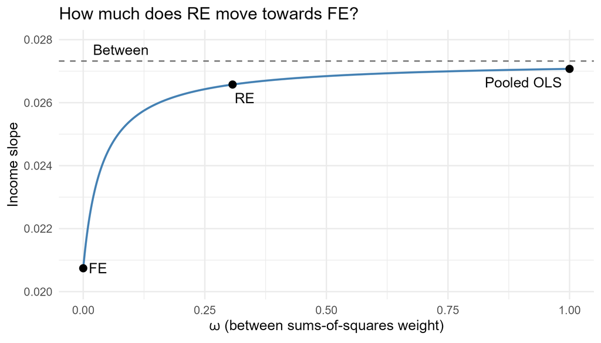

The RE slope remains close to pooling even after the between component is downweighted.

### Explore the weighting relationship

Move the slider. The sample’s sums of squares are held fixed. This is a sensitivity illustration, not an estimated alternative model or an exogeneity test.

Between-component weight ω: **0.307**

Implied slope: **0.02658** · Effective weight on the between slope: **88.7%**

ω = 0 gives FE; ω = 1 gives pooled OLS. The sample RE estimate uses ω ≈ 0.307.

The effective coefficient weight is $\omega B_{xx}/(W_{xx}+\omega B_{xx})$, not $\omega$ itself. A large between sum of squares remains influential after downweighting. This scalar identity does not imply a universal ordering of coefficients in multiple-regressor models.

### Three questions, three tests · §§15.4.1–15.4.3

Model choice involves two separate questions. Keep the tests attached to the question they answer.

| Question | Test | Estimators compared | Robust to clustering? |
| --- | --- | --- | --- |
| Is there a household component, $\sigma_u^2>0$? | LM, eq. 15.35 | Pooled vs RE | Conventional form: no |
| Is the component related to income? | Hausman, eq. 15.36 | FE vs RE | Conventional form: no |
| The same question, in regression form | Mundlak, eqs. 15.38–15.39 | $\gamma=0$ in an augmented regression | Yes, with clustered SEs |

A small LM p-value says household effects exist. It says nothing about whether RE is consistent. That is the job of the Hausman and Mundlak tests.

### Is there a household component? · §15.4.1

Test $H_0:\sigma_u^2=0$ against $H_1:\sigma_u^2>0$. Under $H_0$ the model reduces to pooled OLS, so the LM test needs only the pooled residuals $\hat e_{it}$. For a balanced panel (eq. 15.35):

$$LM=\sqrt{\frac{NT}{2(T-1)}}\left\{\frac{\sum_{i=1}^{N}\left(\sum_{t=1}^{T}\hat e_{it}\right)^2}{\sum_{i=1}^{N}\sum_{t=1}^{T}\hat e_{it}^{2}}-1\right\}.$$

**Intuition.** Squaring each household’s residual sum produces the squared residuals *plus* cross-products such as $2\hat e_{i1}\hat e_{i2}$. Without a household component, the cross-products sum to roughly zero and the ratio is close to one. A household component makes residuals from the same household move together, so the cross-products are positive and $LM$ is large.

Under $H_0$, $LM\sim N(0,1)$ in large samples. Because the alternative is one-sided, reject at the 5% level if $LM>1.645$. A negative $LM$ is not evidence of household effects.

### Does the component move with income? · §15.4.2

Under $H_0$ (no correlation between $u_i$ and income), FE and RE are both consistent and should be close in large samples. Under $H_1$, only FE is consistent. The Hausman test for a single coefficient (eq. 15.36) is

$$t=\frac{b_{FE}-b_{RE}}{\sqrt{\operatorname{se}(b_{FE})^2-\operatorname{se}(b_{RE})^2}}.$$

The denominator is unusual. It relies on eq. 15.37,

$$\operatorname{var}(b_{FE}-b_{RE})=\operatorname{var}(b_{FE})-\operatorname{var}(b_{RE}),$$

which holds because Hausman showed that $\operatorname{cov}(b_{FE},b_{RE})=\operatorname{var}(b_{RE})$ when RE is **efficient**. RE is efficient only under the conventional assumptions: homoskedastic, serially uncorrelated $e_{it}$. With several coefficients, software reports the joint version, which is $\chi^2(K_S)$.

Two weaknesses motivate §15.4.3. First, the formula is not made robust by inserting clustered standard errors: once RE is not efficient, eq. 15.37 no longer holds, so the denominator is simply the wrong variance. Second, in finite samples $\operatorname{se}(b_{FE})^2-\operatorname{se}(b_{RE})^2$ can be negative, and the statistic is then undefined.

### The Mundlak approach: a regression-based Hausman test · §15.4.3

**The idea.** Suppose households with persistently higher income also have systematically different stable tastes for liquor. Then the household effect is related to income, but perhaps mainly through the household’s *average* income level. Mundlak proposed modelling exactly that part:

$$u_i=a+\gamma\bar x_i+c_i, \qquad E(c_i\mid x_{i1},\ldots,x_{iT})=0.$$

Here $\gamma\bar x_i$ is the part of the household effect that moves with average income, and $c_i$ is the remainder, assumed unrelated to income. Substituting into the model gives the augmented regression (eq. 15.39, one regressor):

$$y_{it}=\delta+\beta x_{it}+\gamma\bar x_i+c_i+e_{it},\qquad \delta=\alpha+a.$$

**The test.** If $\gamma=0$, the household effect is unrelated to average income, which is the RE restriction in this representation. Test $H_0:\gamma=0$ with household-clustered inference. With several time-varying regressors, add one mean for each and use a joint Wald test with $\chi^2(K_S)$.

**Why prefer it to eq. 15.36?** The regression version can use cluster-robust standard errors, and a Wald statistic can never be negative.

**What it does not do.** It examines one specified form of dependence, a linear relation with $\bar x_i$. It is not an omnibus proof that $u_i$ is independent of income.

Two results from POE5 (Tables 15.6–15.7) are worth knowing:

1. Estimating the augmented regression by pooled OLS or by RE gives the **same** $\hat\beta$ and $\hat\gamma$, and $\hat\beta$ equals the FE estimate. Holding $\bar x_i$ fixed, $\beta$ can only be learned from within-household changes.
2. Mundlak is also a **model**, not only a test (§15.4.6). Once the means are included and $c_i$ is plausibly unrelated to the regressors, the augmented equation can be estimated by RE. Unlike FE, this keeps time-invariant regressors such as education in a wage equation. The liquor data have no time-invariant regressor, so this advantage is not visible today.

## 3. The econometric lab

Open `panel_data_02.R`. It runs independently of the Lecture 1 session. The data, preparation and numerical conventions are supplied. Household-clustered inference uses the CR1 correction and a $t_{39}$ reference throughout.

### Lab 2.1 · What does clustering change?

**Question:** Does allowing within-household dependence change the pooled slope?  
**Prediction:** Does the coefficient change, the standard error, or both?

```r
pooled <- lm(liquor ~ income, data = panel)
summary(pooled)$coefficients
vc_pooled_cluster <- vcovCL(pooled, cluster = panel$hh,
                            type = "HC1", cadjust = TRUE)
coeftest(pooled, vcov. = vc_pooled_cluster, df = G - 1)
```

**Result:** The slope stays **0.02707**.  
The standard error rises from **0.00533** to **0.00768**.  
**Interpretation:** Conventional inference understates uncertainty here; clustering need not increase standard errors in every sample.  
**Decision:** Improve the inference without claiming that pooling’s identification concern has disappeared.

### Lab 2.2 · Is there a household component?

**Question:** Is there evidence that $\sigma_u^2>0$?  
**Prediction:** Lab 2.1 showed that clustering raised the pooled SE. What does that suggest about the residual cross-products in eq. 15.35?

```r
panel$e_pooled <- resid(pooled)
household_sums <- panel |>
  group_by(hh) |>
  summarise(e_sum = sum(e_pooled))
LM <- sqrt(NT / (2 * (TT - 1))) *
  (sum(household_sums$e_sum^2) / sum(panel$e_pooled^2) - 1)
c(LM = LM, p_one_sided = pnorm(LM, lower.tail = FALSE))

# Cross-check with plm:
pooled_panel <- plm(liquor ~ income, data = panel,
                    index = c("hh", "year"), model = "pooling")
plmtest(pooled_panel, effect = "individual", type = "honda")  # LM, one-sided
plmtest(pooled_panel, effect = "individual", type = "bp")     # LM^2, chi^2(1)
```

**Result:** $LM\approx4.55>1.645$. We reject $H_0:\sigma_u^2=0$.  
**Interpretation:** Residuals from the same household move together. This is the same dependence that made the conventional pooled SE too small in Lab 2.1, and it is why $\hat\omega$ is well below one.  
**Decision:** Pooled OLS with conventional SEs is not adequate. The test does **not** tell us whether RE is consistent.

`type = "bp"` reports the original Breusch–Pagan statistic $LM^2$ against a two-sided $\chi^2(1)$. POE5 recommends the one-sided $LM$ (footnote 11), which `type = "honda"` reports. If you use $LM^2$, the one-sided 5% critical value is $2.706=1.645^2$, and only when $LM>0$.

### Lab 2.3 · How far does RE move towards FE?

**Question:** Where does RE lie relative to pooling and FE?  
**Prediction:** Does a between weight below one guarantee numerical proximity to FE?

```r
random <- plm(liquor ~ income, data = panel, index = c("hh", "year"),
              model = "random", effect = "individual", random.method = "swar")
sigma_e2 <- random$ercomp$sigma2[["idios"]]
sigma_u2 <- random$ercomp$sigma2[["id"]]
omega  <- sigma_e2 / (sigma_e2 + TT * sigma_u2)
lambda <- 1 - sqrt(omega)

panel <- panel |>
  mutate(
    constant_star = 1 - lambda,
    income_star   = income - lambda * income_mean,
    liquor_star   = liquor - lambda * liquor_mean
  )
random_manual <- lm(liquor_star ~ 0 + constant_star + income_star, data = panel)
coef(random_manual)
coef(random)
```

**Result:** $\hat\sigma_e^2=0.96403$, $\hat\sigma_u^2=0.72512$, $\hat\omega=0.30708$, and the RE income slope is **0.02658**.  
**Interpretation:** Large between variation keeps RE close to pooling.  
**Decision:** Similar pooled and RE estimates are not independent confirmation of a causal effect.

### Lab 2.4 · Do FE and RE differ? The conventional Hausman test

**Question:** Is the FE–RE difference large relative to its conventional standard error?  
**Prediction:** The estimates differ by about 0.006. Is that large?

```r
fixed <- plm(liquor ~ income, data = panel, index = c("hh", "year"),
             model = "within", effect = "individual")
b_fe  <- coef(fixed)[["income"]]
b_re  <- coef(random)[["income"]]
se_fe <- sqrt(vcov(fixed)["income", "income"])    # conventional
se_re <- sqrt(vcov(random)["income", "income"])   # conventional
t_hausman <- (b_fe - b_re) / sqrt(se_fe^2 - se_re^2)
c(se_fe = se_fe, se_re = se_re, t = t_hausman,
  p = 2 * pnorm(-abs(t_hausman)))

phtest(fixed, random)   # chi^2(1); equals t_hausman^2 with one regressor
```

**Result:** Conventional SEs are about **0.0209** (FE) and **0.0070** (RE), giving $t\approx-0.30$, $\chi^2(1)\approx0.09$ and $p\approx0.77$.  
**Interpretation:** The estimates are close relative to the precision of the difference. We do not reject the RE restriction under the conventional assumptions.  
**Decision:** Lab 2.2 showed that errors are dependent within households, which is not a problem for RE. But the conventional test also assumes no remaining heteroskedasticity or serial correlation in $e_{it}$. We need a version that does not rely on that, which is Lab 2.6.

**Deliberate misconception:** A classmate inserts the *clustered* SEs from the hook table into eq. 15.36:  
$(0.02074-0.02658)/\sqrt{0.01943^2-0.00746^2}\approx-0.33.$ “Now the Hausman test is cluster-robust.” Why is this calculation unjustified, even though the number looks similar?

**Correction**

The denominator in eq. 15.36 is valid only because $\operatorname{cov}(b_{FE},b_{RE})=\operatorname{var}(b_{RE})$, which requires RE to be efficient. Using clustered SEs means we no longer assume that. Then RE is not efficient, eq. 15.37 fails, and the denominator is not the variance of the difference. The similar number is a coincidence of this sample, not a validation. Use the Mundlak regression with clustered SEs instead.

### Lab 2.5 · What happens when mean income is included?

**Question:** Can we separate the within and between relationships?  
**Prediction:** Which coefficient should reproduce FE?

```r
mundlak <- lm(liquor ~ income + income_mean, data = panel)
vc_mundlak_cluster <- vcovCL(mundlak, cluster = panel$hh,
                             type = "HC1", cadjust = TRUE)
mundlak_inference <- coeftest(mundlak, vcov. = vc_mundlak_cluster, df = G - 1)
mundlak_inference

# Optional: RE on the augmented equation gives the same beta and gamma.
# The quasi-demeaned mean regressor is (1 - lambda) * income_mean.
mundlak_re <- lm(liquor_star ~ 0 + constant_star + income_star +
                   I((1 - lambda) * income_mean), data = panel)
coef(mundlak_re)
```

**Result:** Current-income coefficient **0.02074**; mean-income coefficient **0.00658**. The RE version reproduces both. Re-express the model:

$$y_{it}=\delta+\beta(x_{it}-\bar x_i)
+(\beta+\gamma)\bar x_i+c_i+e_{it}.$$

**Interpretation:** $\beta$ is the within slope, and $\beta+\gamma$ is the between slope. Here $0.02074+0.00658\approx0.02732$. So $\gamma$ is the **between-minus-within** difference, and $\gamma=0$ says that the two sources of variation tell the same story.  
**Decision:** The coefficients now have an explicit within–between interpretation. The current-income coefficient equals FE in this specification. Its CR1 SE need not be identical, because the design matrices have different numbers of columns.

### Lab 2.6 · Does the robust diagnostic settle model choice?

**Question:** Is there strong evidence against $\gamma=0$?  
**Prediction:** Distinguish a nonzero point estimate from a precisely estimated difference.

```r
mundlak_test <- mundlak_inference["income_mean", , drop = FALSE]
mundlak_test
coefci(mundlak, vcov. = vc_mundlak_cluster, df = G - 1)["income_mean", ]
```

| Mean-income coefficient | Clustered SE | Test reference | Two-sided p-value |
| --- | --- | --- | --- |
| 0.006579 | 0.020807 | $t_{39}$ | 0.7535 |

**Interpretation:** We do not reject the restriction. The estimated within–between difference is uncertain. The robust test agrees with the conventional Hausman test in Lab 2.4 ($p\approx0.77$), but only the robust test is valid without assuming homoskedastic, serially uncorrelated $e_{it}$.  
**Decision:** RE remains a possible specification if its assumptions are credible. Non-rejection does not establish them.

**Deliberate misconception:** “The p-value is large, so stable household preferences are unrelated to income and RE is valid.” Replace this with a defensible statement.

**Correction**

The test provides little evidence against the restriction in this specification. It does not prove the restriction, eliminate power concerns, or establish strict exogeneity of the time-varying error. With a clustered SE about three times the estimate, the test could not have detected a within–between difference of moderate size. Economic reasoning still matters.

### Lab 2.7 · What would you report?

**Question:** What is a defensible answer to the original question?  
**Prediction:** Choose a primary interpretation before comparing intervals.

**R action:** Run the script’s Lab 2.7 to construct the following table and coefficient plot.

| Model | Income slope | Clustered SE | 95% interval |
| --- | --- | --- | --- |
| Pooled | 0.027073 | 0.007684 | [0.011530, 0.042615] |
| FE | 0.020742 | 0.019427 | [−0.018553, 0.060037] |
| RE | 0.026575 | 0.007458 | [0.011489, 0.041662] |

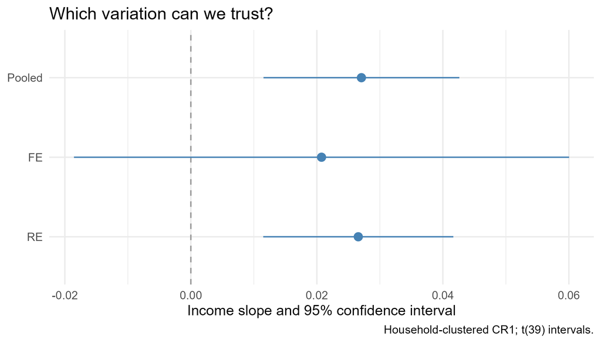

Coefficient estimates and household-clustered intervals using a common documented CR1 convention and t with 39 degrees of freedom.

**Interpretation:** FE supplies a smaller, uncertain within estimate; RE supplies greater precision under stronger restrictions.  
**Decision:** A reporting recommendation needs an argument about the economic comparison, not just a p-value or standard error.

**Suggested conclusion:** There is clear evidence of a household component (LM test). The estimated within-household association between income and liquor expenditure is positive but uncertain. RE gives a more precise positive estimate by using between-household information. Neither the conventional Hausman test nor the cluster-robust Mundlak test rejects its additional restriction, but these data alone do not establish that restriction or a causal income response.

## 4. The AI audit

> We observe 40 households for three periods. An LM test for household effects gives LM ≈ 4.55. The FE income slope is 0.02074 and the RE slope is 0.02658. Their household-clustered standard errors are 0.01943 and 0.00746. A Mundlak regression gives a household-mean-income coefficient of 0.00658, a clustered standard error of 0.02081, and a two-sided p-value of 0.7535.

> An analyst writes: “The LM test shows random effects are present, and the large Mundlak p-value proves RE is valid. Because RE is more precise, we should report only RE and interpret its coefficient causally.” Evaluate this recommendation in fewer than 200 words. Separate the LM result, the RE restriction, precision and causal interpretation. Recommend what to report.

**Audit:** Does the response (1) state that the LM test concerns the presence of $u_i$, not its relation to income, (2) distinguish non-rejection from proof, (3) explain why precision alone cannot choose a model, (4) retain exogeneity of the time-varying error, and (5) connect reporting to the economic question?

**Stress-test prompt:**

> Suppose credible prior evidence shows that stable household preferences are strongly related to average income, but the test still gives p = 0.7535. Should the test overrule that evidence? Explain.

**Expected reasoning:** No. A weakly informative diagnostic cannot validate an assumption contradicted by credible substantive knowledge. FE or a suitable correlated-effects model can address the stable component; neither automatically resolves time-varying endogeneity.

## 5. Exit problem

A researcher clusters RE standard errors by firm and says: “Now RE remains consistent even if managerial ability is correlated with employment.” Is this correct?

**Expected answer and misconceptions**

No. Clustering changes estimated uncertainty, not regressor–error correlation. “Robust” does not mean robust to endogeneity. Switching to ordinary heteroskedasticity-robust errors does not solve this. FE can remove a stable additive managerial component, but does not automatically remove all endogeneity.

**What comes next · §15.4.6:** Year indicators can address common time effects; household FE alone cannot. Panel IV methods may be needed for remaining endogeneity. Dynamic panels introduce further difficulties. These are extensions, not extra live estimation tasks today.

## Assessment practice · outside live time

**Constructed examination example; not liquor data.** Municipalities are observed over time. Recycling is measured in percentage points; an annual collection charge is measured in hundreds of euros.

| Model | Charge coefficient | Conventional SE | Municipality-clustered SE |
| --- | --- | --- | --- |
| FE | 0.80 | 0.40 | 0.50 |
| RE | 1.40 | 0.20 | 0.25 |

An LM test for municipality effects gives $LM=6.2$. A Mundlak test with municipality-clustered SEs gives $p=0.18$.

### Part A · individual reasoning

1. Interpret the FE estimate for a €200 increase.
2. What does $LM=6.2$ tell you? Does it support using RE rather than FE?
3. Compute the Hausman $t$-statistic (eq. 15.36) with the conventional SEs. What do you conclude at the 5% level?
4. Could you instead compute eq. 15.36 with the clustered SEs? Explain.
5. Does $p=0.18$ establish that RE is valid?
6. Give a stable characteristic that could undermine RE.
7. Would clustering standard errors resolve that problem?

**Solutions**

1. The fitted within relationship implies a **1.6 percentage-point** increase in recycling. Causality needs further assumptions.
2. $6.2>1.645$, so we reject $\sigma_u^2=0$: municipality effects are present, and pooled OLS with conventional SEs is inadequate. It does not choose between RE and FE, because it says nothing about whether the effects are related to the charge.
3. $t=(0.80-1.40)/\sqrt{0.40^2-0.20^2}=-0.60/0.3464\approx-1.73$. Since $|t|<1.96$, we do not reject at 5%, although the evidence is borderline and the test relies on the conventional assumptions.
4. No. Eq. 15.36 relies on RE being efficient, which is precisely what clustering stops assuming. The regression-based (Mundlak) test is the robust alternative.
5. No. It indicates non-rejection at conventional levels, not proof.
6. Persistent environmental preferences might affect both recycling and the chosen charge.
7. No. Clustering addresses covariance and inference, not correlation between charges and omitted preferences.

### Part B · AI allowed

The municipality association wants to forecast the effect of increasing charges. Recommend how to use the FE and RE evidence. Explain the trade-off, one remaining threat even under FE, and an additional analysis or source of evidence that would improve the policy assessment.

| Level | Evidence in the answer |
| --- | --- |
| Insufficient | Selects RE only for precision, treats the LM result as support for RE over FE, or declares FE automatically causal |
| Competent | Explains the extra RE restriction, interprets both diagnostics correctly and identifies a remaining threat |
| Strong | Connects model choice to the proposed policy change and explains how additional evidence addresses a specific identification problem |

## Instructor notes · reveal as needed

**Instructor-only teaching notes**

- **Most important idea:** More precise estimates are useful only when the additional assumptions are credible.
- **Two questions, not one.** The LM test concerns the presence of $u_i$; Hausman and Mundlak concern its relation to income. Students routinely read a significant LM test as “use RE”.
- **Time.** Labs 2.2 and 2.4 are short: one result each. If time is short, show their results without running the code, and keep the misconception in Lab 2.4.
- **Link Labs 2.1 and 2.2.** The clustered SE increase and the positive LM statistic both reflect the same within-household residual correlation.
- **Hausman.** The classroom decision rests on the cluster-robust Mundlak t-test. The conventional Hausman test is shown so students can read software output and understand why eq. 15.37 fails under clustering. Do not present it as the robust diagnostic.
- **Mundlak.** Stress that $\gamma$ is between-minus-within. The optional RE check in Lab 2.5 works for any $\lambda$, since the mean regressor and the intercept are scaled by the same factor $1-\lambda$.
- **Notation.** The lecture keeps $\omega$ and $\lambda$ to match the R script; the bridge table maps them to handout V2.1 ($\phi^2$, $\theta$) and POE5 ($\alpha$). Warn that POE5’s $\alpha$ runs in the opposite direction to $\omega$.
- Emphasise that the effective between coefficient weight depends on $B_{xx}$ as well as $\omega$.
- Forty clusters do not guarantee exact finite-sample inference. The shared CR1 correction and $t_{39}$ reference are a transparent working convention; specialised small-sample alternatives are beyond this lecture.
- If time is short, show the variance components without deriving them and focus on the weighting plot and model decision.
- If the class is quiet: “What assumption did we buy the smaller standard error with?”
- Likely AI responses use automatic Hausman rules. Ask what evidence could overturn the suggested model choice.
- A common time effect is different from a household effect. Briefly discuss year indicators, without adding an unverified empirical claim about their impact.

## Sources and reproducibility

Hill, Griffiths and Lim, *Principles of Econometrics*, 5th ed., Chapter 15, especially §§15.3–15.4.6.  
Handout *Comparing Basic Panel Data Estimators* (Version 2.1).  
Handout on the FE and RE error components (`panel_data_FE_RE_errors.qmd`).  
R script `panel_data_02.R`.  
Wooldridge, J. M. (2013), *Introductory Econometrics: A Modern Approach*, 5th ed., Chapters 13–14.  
Data: [liquor5 definition file](https://www.principlesofeconometrics.com/poe5/data/def/liquor5.def) and accompanying R data file: http://www.principlesofeconometrics.com/poe5/data/rdata/liquor5.rdata.